# Social Factors and Children’s Mental Health

- Show All Code
- Hide All Code
- View Source

A cross-sectional study in the Midwest

Author

Walaa Alshaia and Sarah Albalawi

Published

2024-03-19

## R Packages and Setup

```r
knitr::opts_chunk$set(comment = NA)

library(janitor)
library(broom)
library(gt)
library(gtsummary)
library(Hmisc)
library(ggrepel)
library(GGally)
library(knitr)
library(mosaic)
library(naniar)
library(patchwork)
library(simputation)
library(rms)
library(caret)
library(pROC)
library(sessioninfo)
library(tidyverse)

opts_chunk$set(comment=NA)
options(dplyr.summarise.inform = FALSE)

theme_set(theme_bw())
```

# 1 Data Source

The data set used for this study is the National Health Interview Survey (NHIS). The NHIS is part of the Centers for Disease Control and Prevention (CDC) and the main source of statistics on the health of the civilian non-institutionalized population of the United States. The data is collected through interviews conducted at the households of the subjects. The target population are non-institutionalized US citizens, including group homes and shelters. The NHIS aims to obtain a representative sample of the US population through geographically clustered sampling techniques. The data collection is conducted throughout the year, from January to December. For this study, the 2022 NHIS sample child interview data set was used. The file can be found at https://www.cdc.gov/nchs/nhis/2022nhis.htm.

# 2 The Subjects

The subjects of this study are children (any individual below the age of 18) living in civilian non-institutionalized households. The sample is restricted to those in the Midwest region of the U.S.

# 3 Loading and Tidying the Data

## 3.1 Loading the Raw Data

For this study, we will use the 2022 NHIS sample child interview data set. The file can be found at https://www.cdc.gov/nchs/nhis/2022nhis.htm.

```r
R.child22 <- read_csv("child22.csv",
                      guess_max = 4000,
                      show_col_types = FALSE) |>
    mutate(across(where(is.character), as_factor))


dim (R.child22)
```

```
[1] 7464  432
```

## 3.2 Cleaning the Data

In this step, we will mutate, rename, and regroup our variables as needed.

### 3.2.1 Selecting Variables of Interest

Given the extensive size of the raw data set, we will filter the data set to include the variables of interest for our analysis. Additionally, we will narrow the population of interest to those living in the Midwest.

```r
child_raw <- R.child22 |>
  select (HHX,REGION, SEX_C, AGEP_C, MAXEDUCP_C, PHSTAT_C, SDQTOT_C, VIOLENEV_C, HISPALLP_C) |>
  filter(`REGION` == 2, AGEP_C < 97, SEX_C < 10, MAXEDUCP_C < 97 , PHSTAT_C < 10, SDQTOT_C < 90, VIOLENEV_C < 10, HISPALLP_C < 8)

child_raw
```

```
# A tibble: 1,191 × 9
   HHX    REGION SEX_C AGEP_C MAXEDUCP_C PHSTAT_C SDQTOT_C VIOLENEV_C HISPALLP_C
   <fct>   <dbl> <dbl>  <dbl>      <dbl>    <dbl>    <dbl>      <dbl>      <dbl>
 1 H0516…      2     2     17          8        3        8          2          2
 2 H0166…      2     2      7          1        1       14          2          1
 3 H0379…      2     1      5          1        1        2          2          1
 4 H0394…      2     1     10          9        1        0          2          2
 5 H0088…      2     1      5          5        1        6          2          2
 6 H0645…      2     1     17          9        1        4          2          4
 7 H0290…      2     1      7          8        2        3          2          2
 8 H0377…      2     2     13          8        2       11          2          2
 9 H0128…      2     1     15          8        2       88          8          2
10 H0038…      2     1     12          9        1        0          2          2
# ℹ 1,181 more rows
```

We will mutate the variables with levels containing non-relevant values, such as “refused to answer” or “not ascertained”, into `NA`.

```r
child_raw$SEX_C= na_if(child_raw$SEX_C, 7)
child_raw$SEX_C= na_if(child_raw$SEX_C, 8)
child_raw$SEX_C= na_if(child_raw$SEX_C, 9)
child_raw$SDQTOT_C= na_if(child_raw$SDQTOT_C,88)
child_raw$PHSTAT_C = na_if(child_raw$PHSTAT_C, 7)
child_raw$PHSTAT_C = na_if(child_raw$PHSTAT_C, 8)
child_raw$PHSTAT_C = na_if(child_raw$PHSTAT_C, 9)
child_raw$VIOLENEV_C = na_if(child_raw$VIOLENEV_C, 7)
child_raw$VIOLENEV_C = na_if(child_raw$VIOLENEV_C, 8)
child_raw$VIOLENEV_C = na_if(child_raw$VIOLENEV_C, 9)

child_raw
```

```
# A tibble: 1,191 × 9
   HHX    REGION SEX_C AGEP_C MAXEDUCP_C PHSTAT_C SDQTOT_C VIOLENEV_C HISPALLP_C
   <fct>   <dbl> <dbl>  <dbl>      <dbl>    <dbl>    <dbl>      <dbl>      <dbl>
 1 H0516…      2     2     17          8        3        8          2          2
 2 H0166…      2     2      7          1        1       14          2          1
 3 H0379…      2     1      5          1        1        2          2          1
 4 H0394…      2     1     10          9        1        0          2          2
 5 H0088…      2     1      5          5        1        6          2          2
 6 H0645…      2     1     17          9        1        4          2          4
 7 H0290…      2     1      7          8        2        3          2          2
 8 H0377…      2     2     13          8        2       11          2          2
 9 H0128…      2     1     15          8        2       NA         NA          2
10 H0038…      2     1     12          9        1        0          2          2
# ℹ 1,181 more rows
```

### 3.2.2 Converting Variable Types

We will convert the variables into factors, except for `HHX`, which will remain as a character. The variables `AGE_C` and `SDQTOT_C` are the only quantitative variables and will be converted into numeric variables.

```r
child_raw <- child_raw |>
  mutate_if(is.vector, as.factor)|>
  mutate(HHX = as.character(HHX))|>
  mutate(AGEP_C = as.numeric(AGEP_C))|>
  mutate(SDQTOT_C= as.numeric(SDQTOT_C))

child_raw
```

```
# A tibble: 1,191 × 9
   HHX    REGION SEX_C AGEP_C MAXEDUCP_C PHSTAT_C SDQTOT_C VIOLENEV_C HISPALLP_C
   <chr>  <fct>  <fct>  <dbl> <fct>      <fct>       <dbl> <fct>      <fct>
 1 H0516… 2      2         14 8          3               9 2          2
 2 H0166… 2      2          4 1          1              15 2          1
 3 H0379… 2      1          2 1          1               3 2          1
 4 H0394… 2      1          7 9          1               1 2          2
 5 H0088… 2      1          2 5          1               7 2          2
 6 H0645… 2      1         14 9          1               5 2          4
 7 H0290… 2      1          4 8          2               4 2          2
 8 H0377… 2      2         10 8          2              12 2          2
 9 H0128… 2      1         12 8          2              NA <NA>       2
10 H0038… 2      1          9 9          1               1 2          2
# ℹ 1,181 more rows
```

### 3.2.3 Changing Variable Names

We will assign meaningful names to the variables of our study.

```r
child22 <- child_raw|>
  select(HHX, SEX_C, AGEP_C, MAXEDUCP_C, PHSTAT_C, SDQTOT_C, VIOLENEV_C, HISPALLP_C)

child22 <- child22 |>
  rename(sex = SEX_C,
         age = AGEP_C,
         race = HISPALLP_C,
         adult_edu = MAXEDUCP_C,
         health_status = PHSTAT_C,
         sdq = SDQTOT_C,
         violence = VIOLENEV_C,
         id = HHX)

child22
```

```
# A tibble: 1,191 × 8
   id      sex     age adult_edu health_status   sdq violence race
   <chr>   <fct> <dbl> <fct>     <fct>         <dbl> <fct>    <fct>
 1 H051614 2        14 8         3                 9 2        2
 2 H016609 2         4 1         1                15 2        1
 3 H037925 1         2 1         1                 3 2        1
 4 H039485 1         7 9         1                 1 2        2
 5 H008818 1         2 5         1                 7 2        2
 6 H064500 1        14 9         1                 5 2        4
 7 H029084 1         4 8         2                 4 2        2
 8 H037799 2        10 8         2                12 2        2
 9 H012805 1        12 8         2                NA <NA>     2
10 H003829 1         9 9         1                 1 2        2
# ℹ 1,181 more rows
```

### 3.2.4 Working with Categorical Predictors

For this project, we have four categorical variables acting as predictors for both analyses and one binary outcome for the logistic regression analysis: `sex`, `race`, `adult_edu`, `health_status`, and `violence`

#### 3.2.4.1 sex variable

We will rename the numeric levels of `sex` into meaningful labels:

```r
child22 <- child22|>
mutate(sex = fct_recode (sex,
                                  "Male"= "1",
                                  "Female"= "2"))
tabyl(child22$sex)
```

```
 child22$sex   n   percent
        Male 613 0.5146935
      Female 578 0.4853065
```

#### 3.2.4.2 race variable

We will rename each category of the `race` variable to clarify the meaning of each level. We will also combine the levels with the lowest frequencies under *other* category.

```r
child22 <- child22 |>
  mutate(
    race = fct_recode(race,
      "Hispanic" = "1",
      "White" = "2",
      "African_American" = "3",
      "Asian" = "4",
      "other" = "5",
      "other" = "6",
      "other" = "7" ))

tabyl(child22$race)
```

```
     child22$race   n    percent
         Hispanic 163 0.13685978
            White 804 0.67506297
 African_American  78 0.06549118
            Asian  63 0.05289673
            other  83 0.06968934
```

#### 3.2.4.3 adult_edu variable

We will start by renaming the `adult_edu` numeric levels into meaningful words:

```r
child22 <- child22 |>
mutate(adult_edu= fct_recode (adult_edu,
                                  "Grade 1-11"= "1",
                                  "12th grade,no diploma"= "2",
                                  "GED"="3",
                                  "High School Graduate"= "4",
                                  "Some college, no degree"= "5",
                                  "Associate degree-nonacademic-"="6",
                                  "Associate degree-academic-"="7",
                                  "Bachelor's degree"="8",
                                  "Master's degree"="9",
                                  "Professional School"="10"))
tabyl(child22$adult_edu)
```

```
             child22$adult_edu   n     percent
                    Grade 1-11  33 0.027707809
         12th grade,no diploma   7 0.005877414
                           GED   9 0.007556675
          High School Graduate 157 0.131821998
       Some college, no degree 172 0.144416457
 Associate degree-nonacademic-  62 0.052057095
    Associate degree-academic- 133 0.111670865
             Bachelor's degree 321 0.269521411
               Master's degree 212 0.178001679
           Professional School  85 0.071368598
```

We will collapse the present levels to the following:

- Incomplete high school
- Complete high school
- Incomplete college
- Associate’s Degree
- Bachelor’s Degree
- Graduate Degree

```r
child22 <- child22 |>
mutate (adult_edu= fct_collapse(adult_edu, incomplete_highschool = c("Grade 1-11", "12th grade,no diploma"),
                                complete_highschool = c("GED", "High School Graduate"),
                                incomplete_college = c("Some college, no degree"),
                                      associate_degree = c("Associate degree-nonacademic-", "Associate degree-academic-"),
                                      bachelors_degree = c("Bachelor's degree"),
                                      graduate_degree = c("Master's degree", "Professional School")))
tabyl(child22$adult_edu)
```

```
     child22$adult_edu   n    percent
 incomplete_highschool  40 0.03358522
   complete_highschool 166 0.13937867
    incomplete_college 172 0.14441646
      associate_degree 195 0.16372796
      bachelors_degree 321 0.26952141
       graduate_degree 297 0.24937028
```

#### 3.2.4.4 health_status variable

We will start by renaming the `health_status` numeric levels into meaningful labels:

```r
child22 <- child22|>
mutate(health_status= fct_recode (health_status,
                                  "Excellent"= "1",
                                  "Very Good"= "2",
                                  "Good"="3",
                                  "Fair"= "4",
                                  "Poor"= "5"))
tabyl(child22$health_status)
```

```
 child22$health_status   n      percent valid_percent
             Excellent 733 0.6154492024   0.615966387
             Very Good 289 0.2426532326   0.242857143
                  Good 141 0.1183879093   0.118487395
                  Fair  24 0.0201511335   0.020168067
                  Poor   3 0.0025188917   0.002521008
                  <NA>   1 0.0008396306            NA
```

We would like to collapse them into the following categories:

- Excellent
- Very Good
- Not very good

```r
child22 <- child22 |>
mutate (health_status= fct_collapse(health_status, "Not very good" = c("Good","Fair", "Poor")))
tabyl(child22$health_status)
```

```
 child22$health_status   n      percent valid_percent
             Excellent 733 0.6154492024     0.6159664
             Very Good 289 0.2426532326     0.2428571
         Not very good 168 0.1410579345     0.1411765
                  <NA>   1 0.0008396306            NA
```

#### 3.2.4.5 violence variable

We will rename the `violence` numeric levels into meaningful labels:

```r
child22 <- child22|>
mutate(violence = fct_recode (violence,
                                  "Yes"= "1",
                                  "No"= "2"))
tabyl(child22$violence)
```

```
 child22$violence    n    percent valid_percent
              Yes   90 0.07556675    0.07698888
               No 1079 0.90596138    0.92301112
             <NA>   22 0.01847187            NA
```

### 3.2.5 Assessment of Missing Values

We will employ the `miss_var_summary` function to assess missing values in the study variables. The two outcomes of the linear and logistic regression (`sdq` and `violence`) have missing values. One of the predictors (`health_status`) also has a missing value.

```r
miss_var_summary(child22)
```

```
# A tibble: 8 × 3
  variable      n_miss pct_miss
  <chr>          <int>    <dbl>
1 violence          22   1.85
2 sdq               18   1.51
3 health_status      1   0.0840
4 id                 0   0
5 sex                0   0
6 age                0   0
7 adult_edu          0   0
8 race               0   0
```

### 3.2.6 Arranging the Tibble

This is the count of the final data set `child22` after refining the variables of interest:

```r
dim(child22)
```

```
[1] 1191    8
```

we have 1191 observations and 8 variables of interest (including `id`).

# 4 The Tidy Tibble

## 4.1 Listing the Tibble

We will observe the finalized version of our data set after cleaning and filtering the variables:

```r
child22
```

```
# A tibble: 1,191 × 8
   id      sex      age adult_edu             health_status   sdq violence race
   <chr>   <fct>  <dbl> <fct>                 <fct>         <dbl> <fct>    <fct>
 1 H051614 Female    14 bachelors_degree      Not very good     9 No       White
 2 H016609 Female     4 incomplete_highschool Excellent        15 No       Hisp…
 3 H037925 Male       2 incomplete_highschool Excellent         3 No       Hisp…
 4 H039485 Male       7 graduate_degree       Excellent         1 No       White
 5 H008818 Male       2 incomplete_college    Excellent         7 No       White
 6 H064500 Male      14 graduate_degree       Excellent         5 No       Asian
 7 H029084 Male       4 bachelors_degree      Very Good         4 No       White
 8 H037799 Female    10 bachelors_degree      Very Good        12 No       White
 9 H012805 Male      12 bachelors_degree      Very Good        NA <NA>     White
10 H003829 Male       9 graduate_degree       Excellent         1 No       White
# ℹ 1,181 more rows
```

## 4.2 Size and Identifiers

The tibble frame `child22` consists of 1191 rows (*observations*) and 8 columns (*variables*). The `id` functions as our indicator variable, guaranteeing that each row in our data set has a distinct identification. This is demonstrated in the code provided below.

```r
identical(nrow(child22), n_distinct(child22$id))
```

```
[1] TRUE
```

## 4.3 Save The Tibble

We will use the write_rds function to store the finalized data set.

```r
write_rds(child22,"child22.Rds")
```

# 5 The Code Book

## 5.1 Defining the Variables

| Variable | Role | Type | Description |
| --- | --- | --- | --- |
| **id** | Subject Identifier Number | - | Subject character code |
| **sex** | input | Binary | Male and Female |
| **age** | input | Quantitative | Child age in years |
| **race** | input | 5 Categories | Multiple race groups (White, Hispanic, African American, Asian, Other) |
| **adult_edu** | input | 6 Categories | Level of education of the adults in the child’s family (Incomplete high school, Complete high school, Incomplete college, Associate degree, Bachelors degree, Graduate degree ) |
| **health_status** | input | 3 Categories | The health status of the children interviewed (Excellent, Very Good, Not very good) |
| **sdq** | **Outcome** | Quantitative | Strengths and Difficulties Questionnaire (SDQ) total score |
| **violence** | **Outcome** | Binary | The subject is a Victim of/ have witnessed violence (yes or no) |

```r
tbl_summary(select(child22, -id),
        label = list(
            sex = "Sex",
            age = "Age in years",
            race = "Race category",
            adult_health = "Adult Educational level",
            Health_Status = "Child Health Status",
            sdq = "Strengths and Difficulties Questionnaire (SDQ) total score",
            violence = "Victim of or witnessed violence"),
        stat = list( all_continuous() ~
                "{median} [{min} to {max}]" ))
```

| **Characteristic** | **N = 1,191**<sup>1</sup> |
| --- | --- |
| Sex |  |
| Male | 613 (51%) |
| Female | 578 (49%) |
| Age in years | 8.0 [1.0 to 14.0] |
| adult_edu |  |
| incomplete_highschool | 40 (3.4%) |
| complete_highschool | 166 (14%) |
| incomplete_college | 172 (14%) |
| associate_degree | 195 (16%) |
| bachelors_degree | 321 (27%) |
| graduate_degree | 297 (25%) |
| health_status |  |
| Excellent | 733 (62%) |
| Very Good | 289 (24%) |
| Not very good | 168 (14%) |
| Unknown | 1 |
| Strengths and Difficulties Questionnaire (SDQ) total score | 6.0 [1.0 to 31.0] |
| Unknown | 18 |
| Victim of or witnessed violence | 90 (7.7%) |
| Unknown | 22 |
| Race category |  |
| Hispanic | 163 (14%) |
| White | 804 (68%) |
| African_American | 78 (6.5%) |
| Asian | 63 (5.3%) |
| other | 83 (7.0%) |

<sup>1</sup> n (%); Median [Range]

## 5.2 Numerical Description

```r
describe(child22) |> html()
```

child22  
8 Variables 1191 Observations

id

| n | missing | distinct |
| --- | --- | --- |
| 1191 | 0 | 1191 |

lowest : H000027 H000043 H000185 H000206 H000241 , highest: H067509 H067545 H067731 H067745 H067797

sex

| n | missing | distinct |
| --- | --- | --- |
| 1191 | 0 | 2 |

```
 Value        Male Female
 Frequency     613    578
 Proportion  0.515  0.485
```

age

| n | missing | distinct | Info | Mean | Gmd | .05 | .10 | .25 | .50 | .75 | .90 | .95 |
| --- | --- | --- | --- | --- | --- | --- | --- | --- | --- | --- | --- | --- |
| 1191 | 0 | 14 | 0.995 | 7.725 | 4.805 | 1 | 2 | 4 | 8 | 11 | 13 | 14 |

```
 Value          1     2     3     4     5     6     7     8     9    10    11    12
 Frequency     86    91    92    69    73    81    75    78    69    79   101   101
 Proportion 0.072 0.076 0.077 0.058 0.061 0.068 0.063 0.065 0.058 0.066 0.085 0.085

 Value         13    14
 Frequency     98    98
 Proportion 0.082 0.082
```

For the frequency table, variable is rounded to the nearest 0

adult_edu

| n | missing | distinct |
| --- | --- | --- |
| 1191 | 0 | 6 |

```
 Value      incomplete_highschool   complete_highschool    incomplete_college
 Frequency                     40                   166                   172
 Proportion                 0.034                 0.139                 0.144

 Value           associate_degree      bachelors_degree       graduate_degree
 Frequency                    195                   321                   297
 Proportion                 0.164                 0.270                 0.249
```

health_status

| n | missing | distinct |
| --- | --- | --- |
| 1190 | 1 | 3 |

```
 Value          Excellent     Very Good Not very good
 Frequency            733           289           168
 Proportion         0.616         0.243         0.141
```

sdq

| n | missing | distinct | Info | Mean | Gmd | .05 | .10 | .25 | .50 | .75 | .90 | .95 |
| --- | --- | --- | --- | --- | --- | --- | --- | --- | --- | --- | --- | --- |
| 1173 | 18 | 31 | 0.995 | 7.665 | 6.1 | 1 | 2 | 3 | 6 | 11 | 16 | 19 |

lowest : 1 2 3 4 5 , highest: 27 28 29 30 31

violence

| n | missing | distinct |
| --- | --- | --- |
| 1169 | 22 | 2 |

```
 Value        Yes    No
 Frequency     90  1079
 Proportion 0.077 0.923
```

race

| n | missing | distinct |
| --- | --- | --- |
| 1191 | 0 | 5 |

```
 Value              Hispanic            White African_American            Asian
 Frequency               163              804               78               63
 Proportion            0.137            0.675            0.065            0.053

 Value                 other
 Frequency                83
 Proportion            0.070
```

# 6 Linear Regression Plans

## 6.1 My First Research Question

Among children in the Midwest, Do specific social factors (age, sex, race, health status, and parental educational level) contribute to their mental health status score?

## 6.2 My Quantitative Outcome

For this research question, we will use the *Strengths and Difficulties Questionnaire* (**SDQ**) score to measure the subjects’ mental health status. The outcome is named `sdq` in the tibble. We are interested in using this outcome because it is an objective measure of the children mental health status. Hence, it will be a reliable tool in exploring potential associations with social factors, namely their age, sex, race, health status, and parental educational level.

```r
count(complete.cases(child22$sdq))
```

```
n_TRUE
  1173
```

There are 1173 cases with complete `sdq` score values.

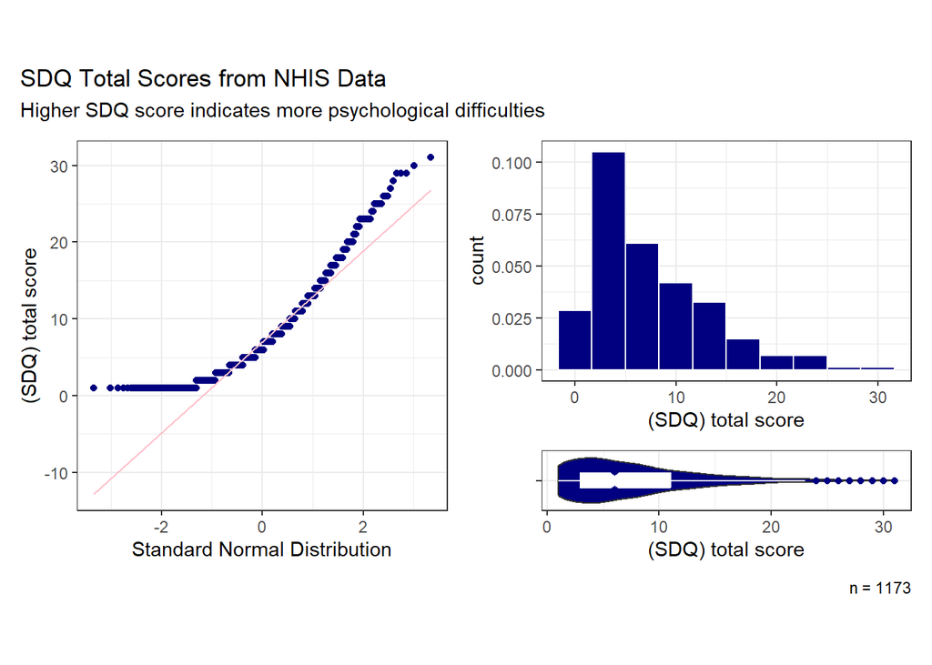

```r
p1 <- ggplot(child22, aes(sample = sdq)) +
  geom_qq(col = "navyblue") + geom_qq_line(col = "pink") +
  theme(aspect.ratio = 1) +
    labs(y = "(SDQ) total score",
         x = "Standard Normal Distribution")

p2 <- ggplot(child22, aes(x = sdq)) +
  geom_histogram(aes(y = stat(density)),
                 bins = 10, fill = "navyblue", col = "white") +
  stat_function(fun = dnorm,
                args = list(mean = mean(child22$sdq),
                            sd = sd(child22$sdq)),
                col = "pink", lwd = 1.5) +
  labs(y = "count", x = "(SDQ) total score")

p3 <- ggplot(child22, aes(x = sdq, y = "")) +
  geom_violin(fill = "navyblue") +
  geom_boxplot(width = 0.3, col = "white", notch = TRUE,
               outlier.color = "navyblue") +
  labs(x = "(SDQ) total score", y = "")

p1 + (p2 / p3 + plot_layout(heights = c(4,1))) +
  plot_annotation(title = "SDQ Total Scores from NHIS Data",
       subtitle = "Higher SDQ score indicates more psychological difficulties",
       caption = "n = 1173")
```

The outcome is not normally distributed, rather, it is remarkably right skewed. A transformation should be considered.

```r
describe(child22$sdq)
```

```
child22$sdq
       n  missing distinct     Info     Mean      Gmd      .05      .10
    1173       18       31    0.995    7.665      6.1        1        2
     .25      .50      .75      .90      .95
       3        6       11       16       19

lowest :  1  2  3  4  5, highest: 27 28 29 30 31
```

As we can see, the outcome `sdq` is a quantitative variable with more than 10 ordinal values.

## 6.3 My Planned Predictors (Linear Model)

The social background encompasses multiple variables including their `sex`, `age`, `race`, `health_status`, and parental educational level `adult_edu`.

The `age` variable is quantitative with more than 10 ordered observations:

```r
describe(child22$age)
```

```
child22$age
       n  missing distinct     Info     Mean      Gmd      .05      .10
    1191        0       14    0.995    7.725    4.805        1        2
     .25      .50      .75      .90      .95
       4        8       11       13       14

Value          1     2     3     4     5     6     7     8     9    10    11
Frequency     86    91    92    69    73    81    75    78    69    79   101
Proportion 0.072 0.076 0.077 0.058 0.061 0.068 0.063 0.065 0.058 0.066 0.085

Value         12    13    14
Frequency    101    98    98
Proportion 0.085 0.082 0.082

For the frequency table, variable is rounded to the nearest 0
```

`race` is a categorical variable with 5 levels. Each level contains over 30 observations:

```r
tabyl(child22$race)
```

```
     child22$race   n    percent
         Hispanic 163 0.13685978
            White 804 0.67506297
 African_American  78 0.06549118
            Asian  63 0.05289673
            other  83 0.06968934
```

We will demonstrate that the total number of candidate predictors we suggest is no more than: 4+(N1-100)/100. N1 is the total number of rows with complete outcome `sdq` data = 1173. 4+(1173-100)/100 = 14.73 ~ 15

The total number of candidate predictors is 5 (`sex`, `age`, `race`, `health_status`, and `adult_edu`) which is way below 15.

The first speculation we hold is that females may be associated with higher `sdq` scores. Our belief is based on the fact that females experience puberty earlier than their male counterpart, which is strongly associated with mental health outcomes. We believe that the child’s health status and parental educational level may have a negative association with their `sdq` mental health score. We also speculate that race may contribute to their mental health score, where children from minority groups may have higher scores compared to other race categories.

# 7 Logistic Regression Plans

## 7.1 My Second Research Question

Among children in the Midwest, Do specific social factors (age, sex, race, health status, and parental educational level) contribute to the probability of witnessing or experiencing violence?

## 7.2 My Binary Outcome

The outcome is the odds of children being victims or witnesses of violence. It is present in the tibble as `violence`. We are interested in using this measure to calculate the odds of children facing adverse events when selected social factors are taken into account. This can be a powerful tool in predicting and preventing child abuse. It can also be used in creating a “profile” of children most likely becoming victims of violence based on their social background.

The outcome variable:

```r
tabyl(child22$violence)
```

```
 child22$violence    n    percent valid_percent
              Yes   90 0.07556675    0.07698888
               No 1079 0.90596138    0.92301112
             <NA>   22 0.01847187            NA
```

`violence` has two categories: yes and no. There are 22 missing values.

## 7.3 My Planned Predictors (Logistic Model)

The social background encompasses multiple variables including the child’s `sex`, `age`, `race`, `health_status`, and parental educational level `adult_edu`.

The `age` variable is quantitative with more than 10 ordered observations:

```r
describe(child22$age)
```

```
child22$age
       n  missing distinct     Info     Mean      Gmd      .05      .10
    1191        0       14    0.995    7.725    4.805        1        2
     .25      .50      .75      .90      .95
       4        8       11       13       14

Value          1     2     3     4     5     6     7     8     9    10    11
Frequency     86    91    92    69    73    81    75    78    69    79   101
Proportion 0.072 0.076 0.077 0.058 0.061 0.068 0.063 0.065 0.058 0.066 0.085

Value         12    13    14
Frequency    101    98    98
Proportion 0.085 0.082 0.082

For the frequency table, variable is rounded to the nearest 0
```

`race` is a 5 level categorical variable, with each level having over 30 observations:

```r
tabyl(child22$race)
```

```
     child22$race   n    percent
         Hispanic 163 0.13685978
            White 804 0.67506297
 African_American  78 0.06549118
            Asian  63 0.05289673
            other  83 0.06968934
```

We will demonstrate that the total number of candidate predictors we suggest is no more than: 4+(N2-100)/100. N2 is the number of the smaller group in the outcome `violence`. In this case N2 = 90. 4+(90-100)/100 = 3.9 ~ 4

The total number of candidate predictors is 5 (`sex`, `age`, `race`, `health_status`, and `adult_edu`) which is more than the suggested number. We will have to remove one predictor before proceeding to analysis.

The first speculation we hold is that younger children (one of the most vulnerable populations) have higher odds of being victims of or witnessing violence. We also believe that the child’s health status and parental educational level may have a negative association with the odds of them being victims or witnesses of violence. Race could contribute to outcome, where children from minority groups may have higher odds of being victims of or witnessing violence compared to children from other race categories.

# 8 Linear Regression Analyses

## 8.1 Missingness

We will use `miss_var_summary` to assess the missingness

```r
miss_var_summary(child22) |> filter(n_miss > 0)
```

```
# A tibble: 3 × 3
  variable      n_miss pct_miss
  <chr>          <int>    <dbl>
1 violence          22   1.85
2 sdq               18   1.51
3 health_status      1   0.0840
```

We’ve noticed that there are missing observations in our outcome variable `sdq` and the predictor variable `health_status`.

### 8.1.1 Single Imputation Approach

For this analysis, we will proceed under the assumption that the observations are missing at random (MAR). Under this assumption, using a single imputation method to handle the missing values is suitable for our predictor `health_status`. We’ll use the `simputation` package to accomplish it. However, we will exclude all the missing observations in our outcome via complete cases.

```r
child22_sub <- child22 |>
  select(sdq, sex, race, adult_edu, age, health_status)|>
  filter(complete.cases(sdq))|>
  impute_cart(health_status ~ sex + race + adult_edu+ age+ sdq)
n_miss(child22_sub)
```

```
[1] 0
```

We used the `n_miss` function to ensure that we obtained zero missing observations.

## 8.2 Outcome Transformation

We will use Box-Cox function to determine whether our outcome requires transformation to improve its skewness.

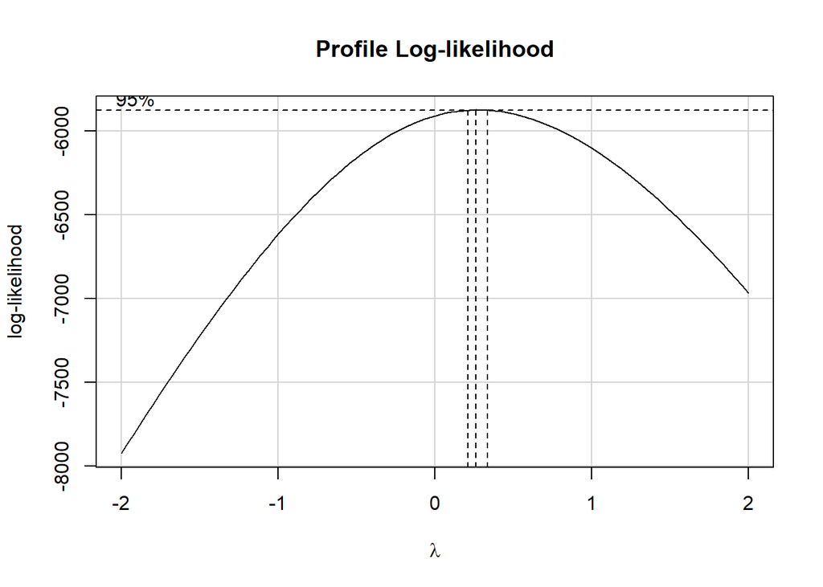

```r
mod_temp <- lm(sdq ~ age + sex + race + adult_edu + health_status, data = child22_sub)

car::boxCox(mod_temp)
```

To verify the given suggestion, we will generate appropriate visualization to assess the skewness

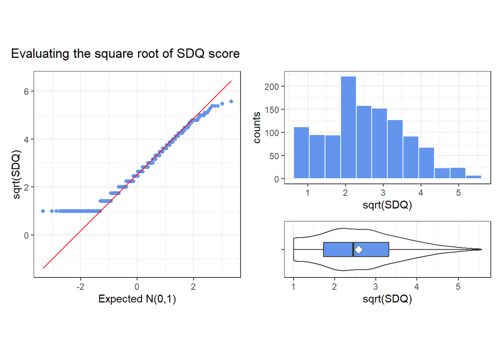

```r
child22_sub <- child22_sub |>
  mutate(sqrtsdq = sqrt(sdq))

p1 <- ggplot(data = child22_sub, aes(sample = sqrtsdq)) +
  geom_qq(col = "cornflowerblue") + geom_qq_line(col = "red") +
  theme(aspect.ratio = 1) +
  labs(x = "Expected N(0,1)", y = "sqrt(SDQ)")

p2 <- ggplot(data = child22_sub, aes(x = sqrtsdq)) +
  geom_histogram(bins = 12 , fill = "cornflowerblue", col = "white") +
  labs(x = "sqrt(SDQ)", y = "counts")

p3 <- ggplot(data = child22_sub, aes(x = sqrtsdq, y = "")) +
  geom_violin() +
  geom_boxplot(fill = "cornflowerblue", width = 0.3,
               outlier.color = "cornflowerblue", outlier.size = 3) +
  stat_summary(fun = "mean", geom = "point",
               shape = 23, size = 3, fill = "white") +
  labs(y = "", x = "sqrt(SDQ)")

p1 + (p2 / p3 + plot_layout(heights = c(2,1)))+
  plot_annotation(title = "Evaluating the square root of SDQ score")
```

The graphs provided demonstrate that although some skewness is still visible in both the normal Q-Q plot and histogram, there has been an improvement. Furthermore, the violin plot demonstrates a reduction of the outliers.

## 8.3 Scatterplot Matrix and Collinearity

We will evaluate collinearity between predictors via scatter plot matrix and variance inflation factors.

- Scatter plot Matrix

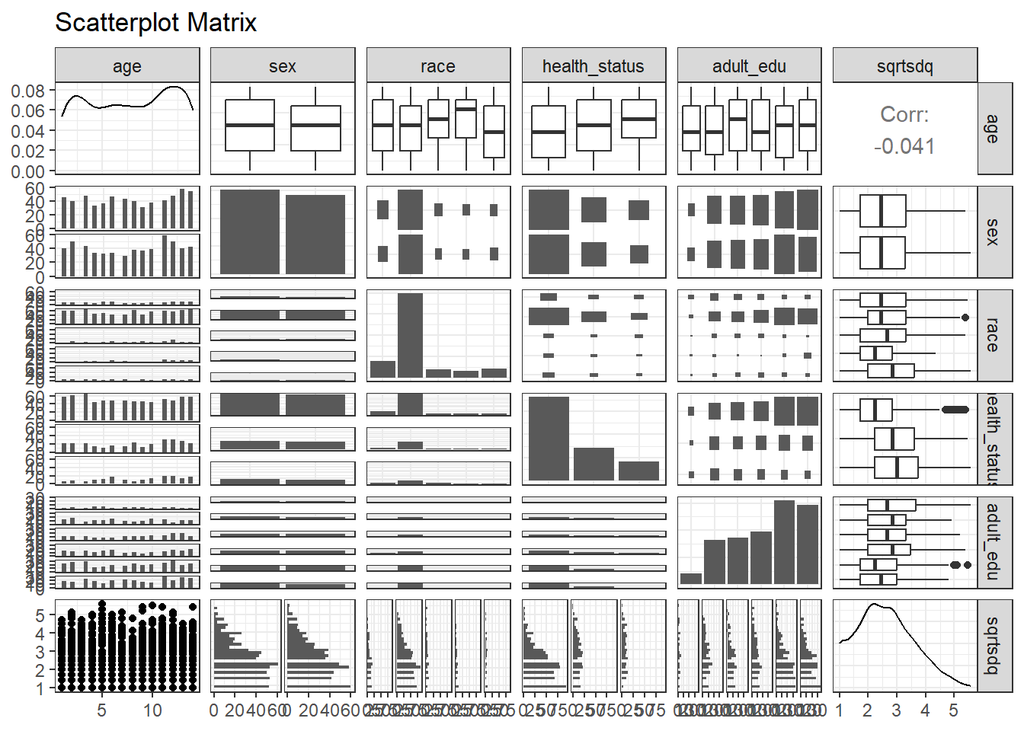

```r
ggpairs(child22_sub, columns = c("age", "sex", "race",
                               "health_status", "adult_edu", "sqrtsdq"),
        title = "Scatterplot Matrix")
```

At the bottom right corner, we observe the density function plot representing our outcome variable `sqrtsdq.` The correlation among the predictors is fairly modest, and the scatter plot matrix reveals no no major concerns regarding collinearity among predictors.

- Checking Variance Inflation Factors

```r
mod_A <- lm(sqrtsdq ~ age + sex + race + health_status + adult_edu, data = child22_sub)

car::vif(mod_A)
```

```
                  GVIF Df GVIF^(1/(2*Df))
age           1.029741  1        1.014762
sex           1.012537  1        1.006249
race          1.222110  4        1.025389
health_status 1.103322  2        1.024886
adult_edu     1.273337  5        1.024458
```

The predictors’ generalized variance inflation factors (GVIF) demonstrate a small level of collinearity. We therefore have no serious concerns with respect to collinearity.

## 8.4 Model A

### 8.4.1 Fitting Model A

Now we will build mod_A “main effect” which incorporates five predictors `age`, `sex`, `race`, `health_status`, `adult_edu` using `lm`.

```r
mod_A <- lm(sqrtsdq ~ age + sex + race + health_status + adult_edu, data = child22_sub)
```

Our next step will be to fit model A “main effect” with the `ols()` function from the `rms` package, which we will use later.

```r
dd <- datadist(child22_sub)
options(datadist = "dd")

mod_A_ols <- ols(sqrtsdq ~ age + sex + race + health_status + adult_edu,
                 data = child22_sub, x = TRUE, y = TRUE)
```

### 8.4.2 Tidied Coefficient Estimates (Model A)

We will use the `tidy` function to obtain the estimates, standard error, lower and upper confidence interval and p-values.

```r
tidy(mod_A, conf.int = TRUE, conf.level = 0.95) |>
  select(term, estimate, se = std.error,
         low95 = conf.low, high95 = conf.high,
         p = p.value) |>
 gt() |> fmt_number(decimals = 3) |> tab_options(table.font.size = 20)
```

| term | estimate | se | low95 | high95 | p |
| --- | --- | --- | --- | --- | --- |
| (Intercept) | 2.603 | 0.168 | 2.272 | 2.933 | 0.000 |
| age | −0.015 | 0.007 | −0.028 | −0.001 | 0.030 |
| sexFemale | −0.014 | 0.055 | −0.123 | 0.095 | 0.801 |
| raceWhite | 0.185 | 0.087 | 0.015 | 0.355 | 0.033 |
| raceAfrican_American | 0.043 | 0.133 | −0.219 | 0.304 | 0.750 |
| raceAsian | −0.150 | 0.145 | −0.435 | 0.135 | 0.302 |
| raceother | 0.300 | 0.130 | 0.045 | 0.555 | 0.021 |
| health_statusVery Good | 0.545 | 0.067 | 0.414 | 0.677 | 0.000 |
| health_statusNot very good | 0.714 | 0.085 | 0.548 | 0.880 | 0.000 |
| adult_educomplete_highschool | −0.173 | 0.168 | −0.503 | 0.158 | 0.306 |
| adult_eduincomplete_college | −0.244 | 0.168 | −0.575 | 0.086 | 0.148 |
| adult_eduassociate_degree | −0.103 | 0.168 | −0.433 | 0.226 | 0.540 |
| adult_edubachelors_degree | −0.422 | 0.165 | −0.746 | −0.098 | 0.011 |
| adult_edugraduate_degree | −0.354 | 0.166 | −0.679 | −0.029 | 0.033 |

### 8.4.3 Summarizing Fit (Model A)

In this section we will use `glance` function to obtain R-squared, Adj.r.squared, sigma, AIC and BIC, nobs, df, and df.residual.

```r
glance(mod_A) |>
  select(r2 = r.squared, adjr2 = adj.r.squared, sigma,
         AIC, BIC, nobs, df, df.residual) |>
  kable(digits = c(3, 3, 2, 1, 1, 0, 0, 0))
```

| r2 | adjr2 | sigma | AIC | BIC | nobs | df | df.residual |
| --- | --- | --- | --- | --- | --- | --- | --- |
| 0.124 | 0.114 | 0.94 | 3209.4 | 3285.4 | 1173 | 13 | 1159 |

The R-squared value indicates that the model accounts for 12.4% of the variation in `sqrtsdq.` The adjusted R-squared is an index and it is is 0.11, and the model is based on 1173 observations, and has 13 df.

### 8.4.4 Regression Diagnostics (Model A)

Here, the code will yield four residual plots

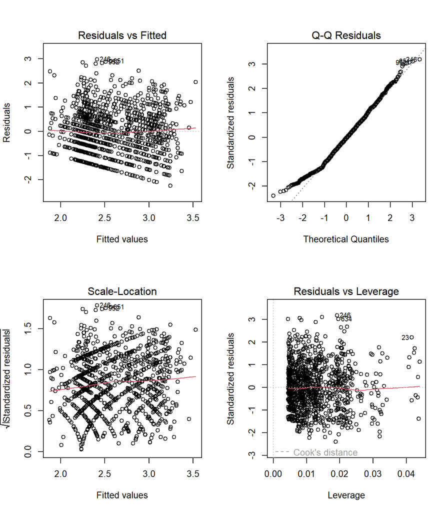

```r
par(mfrow = c(2,2)); plot(mod_A); par(mfrow = c(2,2))
```

Given the outcome’s discrete nature and the presence of four categorical predictors, we note certain patterns in our linearity assumption in the residual vs. fitted plot and the homoscedasticity assumption in the scale-location plots. However, the Q-Q plot of residuals reveals a few outliers at the lower end, albeit not influential as per the residuals vs. leverage plot (nothing passed the Cook’s distance). In conclusion, while there are minor deviations, overall, our assumptions appear to be reasonably met.

## 8.5 Non-Linearity

Presented below is the needed Spearman $\rho^2$ plot.

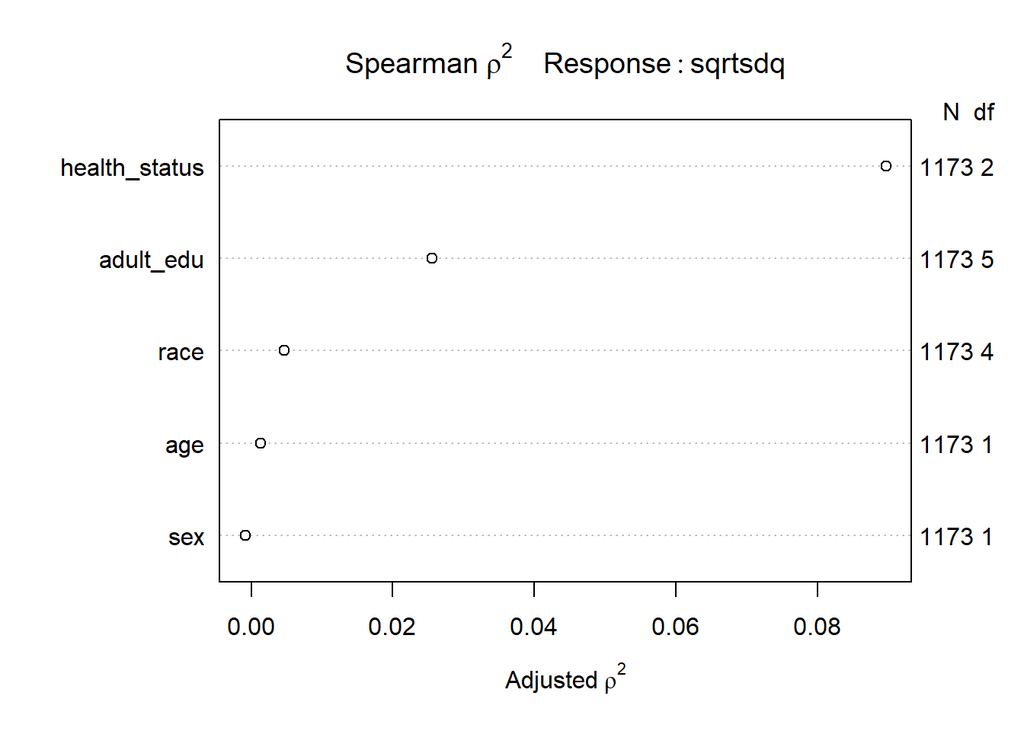

```r
plot(spearman2(sqrtsdq ~ age + sex + race + health_status + adult_edu,
                 data = child22_sub))
```

Based to the Spearman $\rho^2$ plot, the most attractive candidate predictors for non-linear terms are `health_status` and `adult_edu`, respectively. We will include an interaction between `health_status` (2 df) and `adult_edu` (5 df), which is expected to contribute 10 degrees of freedom to our initial model.

**Note**: this approach has received approval from Prof. Thomas Love on 2024-03-17.

## 8.6 Model B

Our Model B will include one non-linear term the interaction between `health_status` and `adult_edu`, this should add about 10 degrees of freedom to our Model A.

### 8.6.1 Fitting Model B

Now we will build augmented model B with interaction term which incorporates five predictors `age`, `sex`, `race`, `health_status`*`adult_edu` using `lm`.

```r
mod_B <- lm(sqrtsdq ~ age + sex + race  + health_status * adult_edu, data = child22_sub)
```

Our next step will be to fit model B with the `ols()` function from the `rms` package.

```r
dd <- datadist(child22_sub)
options(datadist = "dd")

mod_B_ols <- ols(sqrtsdq ~ age + sex + race + health_status * adult_edu, data = child22_sub, x = TRUE, y = TRUE)
```

### 8.6.2 Tidied Coefficient Estimates (Model B)

We will use the `tidy` function to obtain the estimates, standard error, lower and upper confidence interval and p-values.

```r
tidy(mod_B, conf.int = TRUE, conf.level = 0.95) |>
  select(term, estimate, se = std.error,
         low95 = conf.low, high95 = conf.high,
         p = p.value) |>
gt() |> fmt_number(decimals = 3) |> tab_options(table.font.size = 20)
```

| term | estimate | se | low95 | high95 | p |
| --- | --- | --- | --- | --- | --- |
| (Intercept) | 2.754 | 0.229 | 2.306 | 3.203 | 0.000 |
| age | −0.014 | 0.007 | −0.027 | −0.001 | 0.038 |
| sexFemale | −0.011 | 0.056 | −0.121 | 0.098 | 0.840 |
| raceWhite | 0.185 | 0.087 | 0.014 | 0.356 | 0.034 |
| raceAfrican_American | 0.055 | 0.135 | −0.209 | 0.319 | 0.683 |
| raceAsian | −0.168 | 0.146 | −0.454 | 0.119 | 0.251 |
| raceother | 0.296 | 0.131 | 0.039 | 0.553 | 0.024 |
| health_statusVery Good | 0.221 | 0.419 | −0.600 | 1.043 | 0.597 |
| health_statusNot very good | 0.431 | 0.333 | −0.222 | 1.084 | 0.196 |
| adult_educomplete_highschool | −0.218 | 0.244 | −0.696 | 0.259 | 0.370 |
| adult_eduincomplete_college | −0.382 | 0.240 | −0.854 | 0.090 | 0.112 |
| adult_eduassociate_degree | −0.273 | 0.236 | −0.737 | 0.191 | 0.248 |
| adult_edubachelors_degree | −0.609 | 0.230 | −1.061 | −0.158 | 0.008 |
| adult_edugraduate_degree | −0.534 | 0.229 | −0.984 | −0.084 | 0.020 |
| health_statusVery Good:adult_educomplete_highschool | 0.232 | 0.454 | −0.659 | 1.123 | 0.610 |
| health_statusNot very good:adult_educomplete_highschool | −0.061 | 0.381 | −0.809 | 0.688 | 0.873 |
| health_statusVery Good:adult_eduincomplete_college | 0.140 | 0.453 | −0.748 | 1.028 | 0.758 |
| health_statusNot very good:adult_eduincomplete_college | 0.417 | 0.381 | −0.331 | 1.164 | 0.274 |
| health_statusVery Good:adult_eduassociate_degree | 0.385 | 0.448 | −0.493 | 1.264 | 0.390 |
| health_statusNot very good:adult_eduassociate_degree | 0.253 | 0.386 | −0.503 | 1.010 | 0.511 |
| health_statusVery Good:adult_edubachelors_degree | 0.413 | 0.438 | −0.447 | 1.274 | 0.346 |
| health_statusNot very good:adult_edubachelors_degree | 0.405 | 0.387 | −0.355 | 1.164 | 0.296 |
| health_statusVery Good:adult_edugraduate_degree | 0.366 | 0.441 | −0.499 | 1.231 | 0.406 |
| health_statusNot very good:adult_edugraduate_degree | 0.515 | 0.400 | −0.269 | 1.300 | 0.198 |

### 8.6.3 Effects Plot for Model B

Here, we will present a plot of the effects from `plot(summary(modelname))`for this augmented model, using `ols`

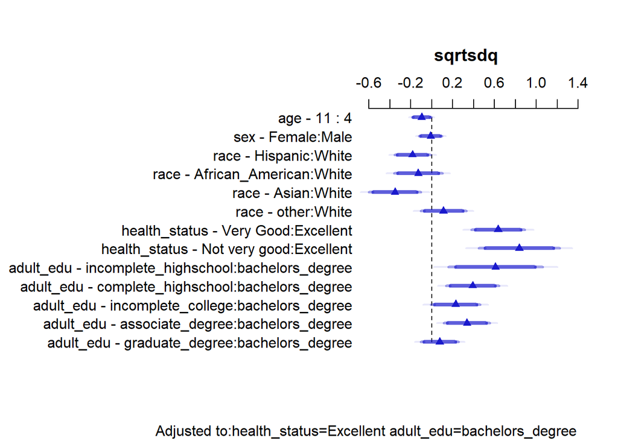

```r
plot(summary(mod_B_ols))
```

### 8.6.4 Summarizing Fit (Model B)

In this section we will use `glance` function to obtain R-squared, Adj.r.squared, sigma, AIC and BIC, nobs, df, and df.residual.

```r
glance(mod_B) |>
  select(r2 = r.squared, adjr2 = adj.r.squared, sigma,
         AIC, BIC, nobs, df, df.residual) |>
  kable(digits = c(3, 3, 2, 1, 1, 0, 0, 0))
```

| r2 | adjr2 | sigma | AIC | BIC | nobs | df | df.residual |
| --- | --- | --- | --- | --- | --- | --- | --- |
| 0.131 | 0.113 | 0.94 | 3220.3 | 3347 | 1173 | 23 | 1149 |

In our Model B, we use 23 degrees of freedom, and obtain an $R^2$ value of 0.131. The R-squared value indicates that the model accounts for 13 % of the variation in `sqrtsdq.` The adjusted R-squared is an index and it is is 0.11, and the model is based on 1173 observations, and has 23 df.

### 8.6.5 Regression Diagnostics (Model B)

Here, the code will yield four residual plots

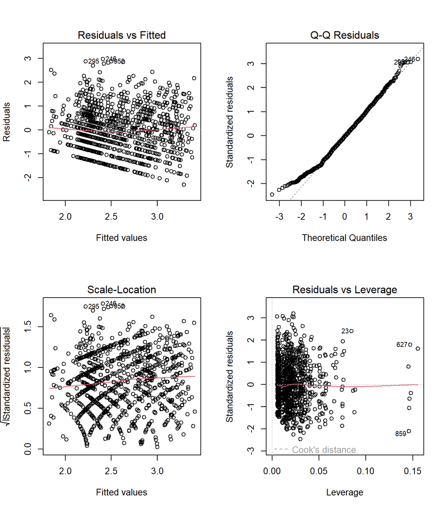

```r
par(mfrow = c(2,2)); plot(mod_B); par(mfrow = c(1,1))
```

Considering the discrete nature of the outcome and the presence of four categorical predictors, we observed certain patterns in the residual vs. fitted plot and the scale-location plots. However, these patterns do not substantially affect the linearity and homoscedasticity assumptions. Additionally, the Q-Q plot of residuals shows a few outliers at both ends. Among these outliers, observations 627 and 859 exhibit high leverage, but they are not influential according to the residuals vs. leverage plot (none exceed the Cook’s distance threshold). In summary, while there are minor deviations, our assumptions seem to be reasonably met overall.

## 8.7 Validating Models A and B

We will use the `validate()` function from the **rms** package to validate our `ols` fits that we previously created by re-sampling.

```r
set.seed(4321); (valA <- validate(mod_A_ols))
```

```
          index.orig training   test optimism index.corrected  n
R-square      0.1238   0.1344 0.1122   0.0223          0.1016 40
MSE           0.8804   0.8638 0.8921  -0.0284          0.9088 40
g             0.3994   0.4115 0.3827   0.0288          0.3707 40
Intercept     0.0000   0.0000 0.1844  -0.1844          0.1844 40
Slope         1.0000   1.0000 0.9297   0.0703          0.9297 40
```

```r
set.seed(4322); (valB <- validate(mod_B_ols))
```

```
          index.orig training   test optimism index.corrected  n
R-square      0.1306   0.1439 0.1107   0.0332          0.0973 40
MSE           0.8736   0.8632 0.8936  -0.0305          0.9041 40
g             0.4124   0.4285 0.3815   0.0471          0.3653 40
Intercept     0.0000   0.0000 0.2737  -0.2737          0.2737 40
Slope         1.0000   1.0000 0.8935   0.1065          0.8935 40
```

After performing the validation, the output provides the R-squared value, MSE (mean squared error), intercept, and slope, along with their respective indices: “index.orig,” “training,” “test,” and “optimism,” which represents the difference between the training and test samples. Additionally, it includes the “index.corrected,” calculated as “index.orig” minus “optimism.”

### 8.7.1 Validated $R^2$, and MSE as well as IC statistics

| Model | Validated $R^2$ | Validated MSE | AIC | BIC | df |
| --- | --- | --- | --- | --- | --- |
| A | 0.102 | 0.9088 | 3209.4 | 3285.4 | 13 |
| B | 0.097 | 0.9041 | 3220.3 | 3347 | 23 |

## 8.8 Final Linear Regression Model

The table above provides information about the validated R-squared, MSE, AIC, and BIC. These values were obtained from a validation comparison between the “augmented model” B and the “main effects” model A, predicting the transformed outcome (sqrtsdq). Validated R-squared represents the percentage of variation in the outcome, while MSE stands for mean squared error, and AIC and BIC are Akaike and Bayesian Information Criteria, respectively. A more favorable fit is indicated by a higher validated R-squared and lower values of MSE, AIC, and BIC. In this case, **model A “main effects”** or the simple model shows a higher validated R-squared value and lower AIC and BIC, suggesting the most desirable fit, despite Model B having a lower validated MSE.Additionally, it’s worth noting that the inclusion of interaction terms in the augmented model yields no apparent improvement.

### 8.8.1 Winning Model’s Parameter Estimates

Here, we will generate the content of mod_A_ols

```r
mod_A_ols
```

```
Linear Regression Model

ols(formula = sqrtsdq ~ age + sex + race + health_status + adult_edu,
    data = child22_sub, x = TRUE, y = TRUE)

                Model Likelihood    Discrimination
                      Ratio Test           Indexes
Obs    1173    LR chi2    155.06    R2       0.124
sigma0.9439    d.f.           13    R2 adj   0.114
d.f.   1159    Pr(> chi2) 0.0000    g        0.399

Residuals

     Min       1Q   Median       3Q      Max
-2.24347 -0.68510 -0.03101  0.61304  2.97395

                              Coef    S.E.   t     Pr(>|t|)
Intercept                      2.6027 0.1684 15.45 <0.0001
age                           -0.0145 0.0067 -2.17 0.0298
sex=Female                    -0.0140 0.0555 -0.25 0.8014
race=White                     0.1848 0.0866  2.13 0.0331
race=African_American          0.0426 0.1334  0.32 0.7498
race=Asian                    -0.1500 0.1452 -1.03 0.3018
race=other                     0.2998 0.1299  2.31 0.0212
health_status=Very Good        0.5453 0.0670  8.14 <0.0001
health_status=Not very good    0.7145 0.0846  8.44 <0.0001
adult_edu=complete_highschool -0.1726 0.1684 -1.02 0.3058
adult_edu=incomplete_college  -0.2440 0.1684 -1.45 0.1477
adult_edu=associate_degree    -0.1031 0.1680 -0.61 0.5396
adult_edu=bachelors_degree    -0.4218 0.1650 -2.56 0.0107
adult_edu=graduate_degree     -0.3540 0.1656 -2.14 0.0328
```

The validated $R^2$ value ( = 0.102) for our Model A

The output provides details about the formula used for the model, along with the number of observations. It includes the estimated residual standard deviation (sigma) and its corresponding degrees of freedom (df), as well as the model’s likelihood ratio test and discrimination indexes. Additionally, it presents a statistical summary, including the minimum, first quartile (1Q), median, third quartile (3Q), and maximum values for “sqrtsdq.” Finally, it lists the coefficient values, standard errors, t-test statistics, and p-values for all predictors.

### 8.8.2 Effects Plot for Winning Model

Here, we will present a plot of the effects from `plot(summary(modelname))`for this simple main effect model, using `ols`

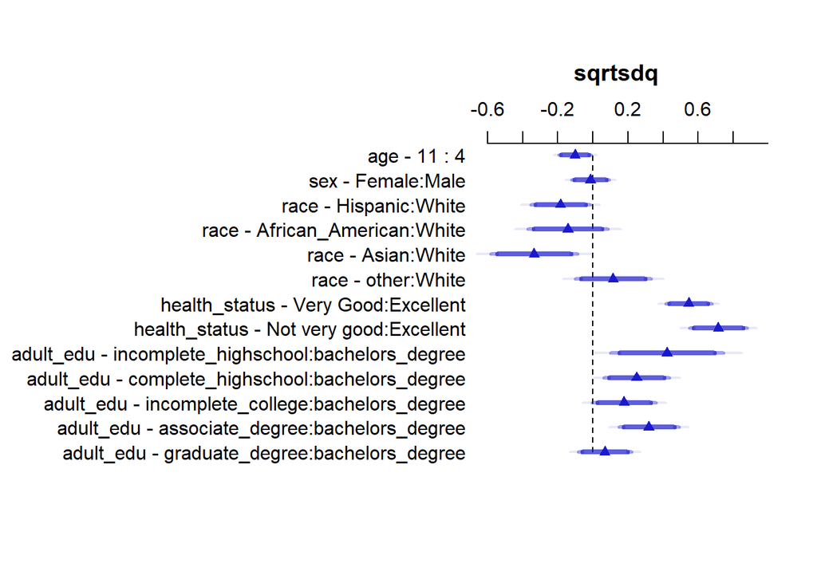

```r
plot(summary(mod_A_ols))
```

### 8.8.3 Numerical Description of Effect Sizes

Here, we will obtain the effects summary of the `ols` model.

```r
summary(mod_A_ols) |> kable(digits = 3)
```

|  | Low | High | Diff. | Effect | S.E. | Lower 0.95 | Upper 0.95 | Type |
| --- | --- | --- | --- | --- | --- | --- | --- | --- |
| age | 4 | 11 | 7 | -0.102 | 0.047 | -0.194 | -0.010 | 1 |
| sex - Female:Male | 1 | 2 | NA | -0.014 | 0.055 | -0.123 | 0.095 | 1 |
| race - Hispanic:White | 2 | 1 | NA | -0.185 | 0.087 | -0.355 | -0.015 | 1 |
| race - African_American:White | 2 | 3 | NA | -0.142 | 0.117 | -0.372 | 0.088 | 1 |
| race - Asian:White | 2 | 4 | NA | -0.335 | 0.127 | -0.583 | -0.086 | 1 |
| race - other:White | 2 | 5 | NA | 0.115 | 0.111 | -0.102 | 0.332 | 1 |
| health_status - Very Good:Excellent | 1 | 2 | NA | 0.545 | 0.067 | 0.414 | 0.677 | 1 |
| health_status - Not very good:Excellent | 1 | 3 | NA | 0.714 | 0.085 | 0.548 | 0.880 | 1 |
| adult_edu - incomplete_highschool:bachelors_degree | 5 | 1 | NA | 0.422 | 0.165 | 0.098 | 0.746 | 1 |
| adult_edu - complete_highschool:bachelors_degree | 5 | 2 | NA | 0.249 | 0.095 | 0.063 | 0.435 | 1 |
| adult_edu - incomplete_college:bachelors_degree | 5 | 3 | NA | 0.178 | 0.092 | -0.003 | 0.359 | 1 |
| adult_edu - associate_degree:bachelors_degree | 5 | 4 | NA | 0.319 | 0.088 | 0.147 | 0.491 | 1 |
| adult_edu - graduate_degree:bachelors_degree | 5 | 6 | NA | 0.068 | 0.078 | -0.085 | 0.220 | 1 |

This effects summary of model A illustrates the impact on `sqrtsdq` when moving from the 25th to the 75th percentile of each variable. The estimates are accompanied by their respective standard errors and 95% confidence intervals, while maintaining the other variables at a constant level.

### 8.8.5 Nomogram of Winning Model

These predicted values are square root.

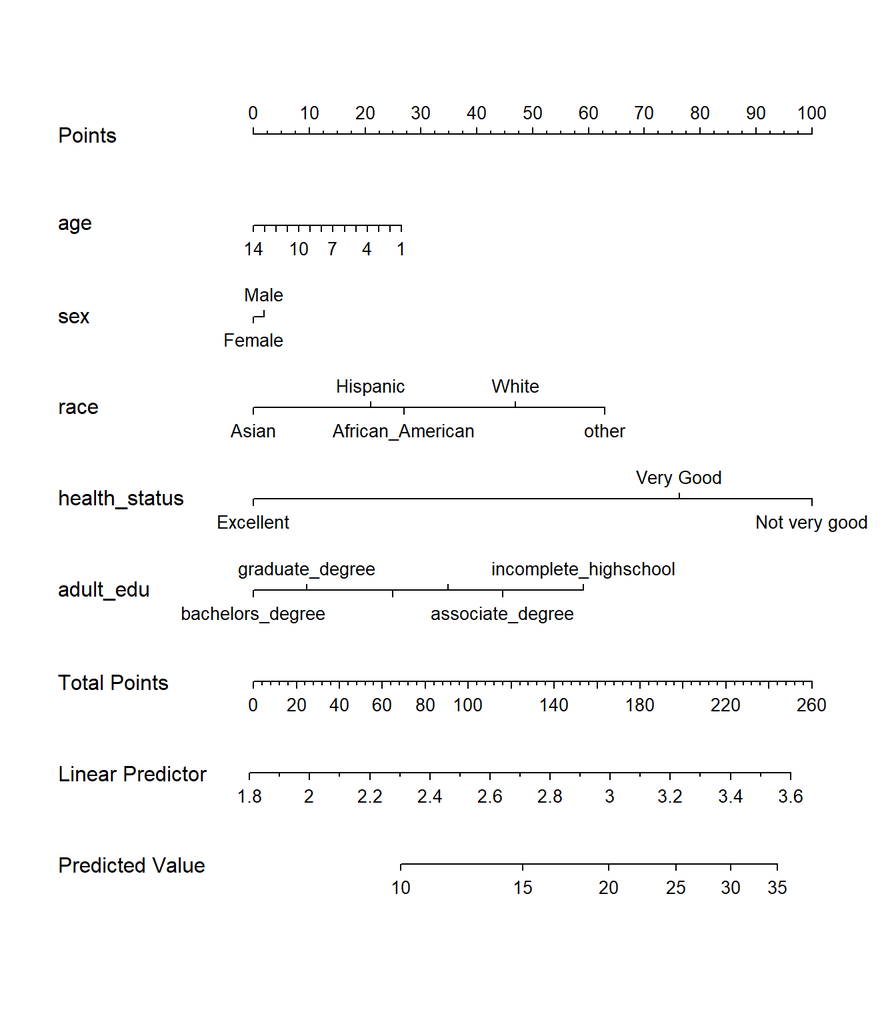

```r
plot(nomogram(mod_A_ols, fun = exp))
```

### 8.8.6 Prediction for a New Subject

We will generate predicted SDQ scores for two children, both female, one of White race and the other Hispanic. Both are 8 years old with reported “not very good” health statuses, and their parental education level is incomplete college education. We will use the code below and then squaring the predictions.

```r
new_subjects <-
  data.frame(age = c(8,8), sex = c("Female", "Female"), race = c("White", "Hispanic"),
             health_status = c("Not very good", "Not very good"), adult_edu = c("incomplete_college", "incomplete_college"))

preds1 <- predict.lm(mod_A, newdata = new_subjects,
                     interval = "prediction", level = 0.95)

(preds1)^2
```

```
       fit      lwr     upr
1 9.781555 1.597199 24.9130
2 8.659805 1.156341 23.1378
```

| Predictor Values | Predicted SDQ | 95% Prediction Interval |
| --- | --- | --- |
| age = 8, sex = Female, race= White, health_status = Not very good, adult_edu = incomplete_college | 9.78 | (1.59, 24.91) |
| age = 8, sex = Female, race= Hispanic, health_status = Not very good, adult_edu = incomplete_college | 8.66 | (1.16, 23.14) |

The code below will generate the predicted values in square root form, and they align with the values obtained from the nomogram plot.

```r
new_subjects <-
  data.frame(age = c(8,8), sex = c("Female", "Female"), race = c("White", "Hispanic"),
             health_status = c("Not very good", "Not very good"), adult_edu = c("incomplete_college", "incomplete_college"))

preds2 <- predict.lm(mod_A, newdata = new_subjects,
                     interval = "prediction", level = 0.95)

preds2
```

```
       fit      lwr      upr
1 3.127548 1.263803 4.991292
2 2.942755 1.075333 4.810176
```

# 9 Logistic Regression Analyses

We will start by creating a data subset including the predictors for the logistic regression analysis:

```r
child22_log <- child22|>
  select(id, sex, age, race, health_status, adult_edu, violence)

child22_log
```

```
# A tibble: 1,191 × 7
   id      sex      age race     health_status adult_edu             violence
   <chr>   <fct>  <dbl> <fct>    <fct>         <fct>                 <fct>
 1 H051614 Female    14 White    Not very good bachelors_degree      No
 2 H016609 Female     4 Hispanic Excellent     incomplete_highschool No
 3 H037925 Male       2 Hispanic Excellent     incomplete_highschool No
 4 H039485 Male       7 White    Excellent     graduate_degree       No
 5 H008818 Male       2 White    Excellent     incomplete_college    No
 6 H064500 Male      14 Asian    Excellent     graduate_degree       No
 7 H029084 Male       4 White    Very Good     bachelors_degree      No
 8 H037799 Female    10 White    Very Good     bachelors_degree      No
 9 H012805 Male      12 White    Very Good     bachelors_degree      <NA>
10 H003829 Male       9 White    Excellent     graduate_degree       No
# ℹ 1,181 more rows
```

Before proceeding any further, we will notice that our outcome `violence` is a factor. We will mutate it into a numeric variable with 0 and 1 levels.

```r
child22_log <- child22_log |> mutate(violence = as.numeric (violence))|> mutate(violence = 2 - violence)
```

## 9.1 Predictor Selection

In the logistic analysis plan, we decided to reduce the number of predictors from 5 variables to 4 variables. All of the predictors included in the model are child social factors including their age, sex, race, and health status. Parental educational level `adult_edu` is the only variable associated with parents. This variable also has the highest number of levels (6 educational levels) and therefore will use more degrees of freedom compared to the rest of the predictors. Based on these facts, we decided to remove this variable from the logistic model.

The finalized logistic model data set will include be:

```r
child22_log <- child22_log|>
   select(-adult_edu)

child22_log
```

```
# A tibble: 1,191 × 6
   id      sex      age race     health_status violence
   <chr>   <fct>  <dbl> <fct>    <fct>            <dbl>
 1 H051614 Female    14 White    Not very good        0
 2 H016609 Female     4 Hispanic Excellent            0
 3 H037925 Male       2 Hispanic Excellent            0
 4 H039485 Male       7 White    Excellent            0
 5 H008818 Male       2 White    Excellent            0
 6 H064500 Male      14 Asian    Excellent            0
 7 H029084 Male       4 White    Very Good            0
 8 H037799 Female    10 White    Very Good            0
 9 H012805 Male      12 White    Very Good           NA
10 H003829 Male       9 White    Excellent            0
# ℹ 1,181 more rows
```

## 9.2 Dealing with missingness

We will observe the number of subjects with missing observations and the proportion of missingness in our data set.

```r
miss_var_summary(child22_log)
```

```
# A tibble: 6 × 3
  variable      n_miss pct_miss
  <chr>          <int>    <dbl>
1 violence          22   1.85
2 health_status      1   0.0840
3 id                 0   0
4 sex                0   0
5 age                0   0
6 race               0   0
```

There is a total of 23 subjects with missing observations and the overall proportion of missingness is 1.9%. In this case, imputing the missing observations is neither essential nor unnecessary, so we will proceed with the imputation process.

We will use the single imputation method using `simpute` function:

```r
set.seed(432)
child22_si <- child22_log |> data.frame() |>
  impute_rhd(violence ~ age + sex + race) |>
  impute_cart(health_status ~ age + sex + race) |>
  as_tibble()

n_miss(child22_si)
```

```
[1] 0
```

## 9.3 Model Y: Main effects model

### 9.3.1 ModelY Results using `glm`

Now we will fit the main effects model using `glm` function.

```r
mody_g <- glm(violence ~ sex + age + race + health_status,
            data = child22_si,
            family = binomial(link = logit))
```

Now we will produce a tidied table with the exponentiated estimates (odd ratios) with a 95% confidence interval.

```r
tidy(mody_g, exponentiate = TRUE,
     conf.int = TRUE, conf.level = 0.95) |>
  select(term, estimate, std.error,
         low95 = conf.low, high95 = conf.high,
         p = p.value) |>
  gt() |>
  fmt_number(decimals = 3) |>
  tab_options(table.font.size = 20)
```

| term | estimate | std.error | low95 | high95 | p |
| --- | --- | --- | --- | --- | --- |
| (Intercept) | 0.028 | 0.426 | 0.012 | 0.062 | 0.000 |
| sexFemale | 1.360 | 0.223 | 0.879 | 2.114 | 0.168 |
| age | 1.059 | 0.028 | 1.003 | 1.119 | 0.040 |
| raceWhite | 1.058 | 0.347 | 0.556 | 2.194 | 0.871 |
| raceAfrican_American | 2.520 | 0.441 | 1.062 | 6.082 | 0.036 |
| raceAsian | 0.425 | 0.787 | 0.064 | 1.654 | 0.276 |
| raceother | 2.116 | 0.456 | 0.857 | 5.229 | 0.100 |
| health_statusVery Good | 1.766 | 0.257 | 1.059 | 2.911 | 0.027 |
| health_statusNot very good | 2.116 | 0.293 | 1.173 | 3.717 | 0.010 |

```r
rms::vif(mody_g)
```

```
                 sexFemale                        age
                  1.008948                   1.016786
                 raceWhite       raceAfrican_American
                  2.344559                   1.785802
                 raceAsian                  raceother
                  1.163887                   1.718125
    health_statusVery Good health_statusNot very good
                  1.157662                   1.196977
```

As we can see, the inflation scores do not exceed the level of potential interaction. Therefore, we have no problems regarding collinearity between the predictors.

### 9.3.2 ModelY Results using `lrm`

We will refit the same model using the `lrm` function.

```r
d <- datadist(child22_si)
options(datadist = "d")

mody_r <- lrm(violence ~ sex + age + race + health_status,
            data = child22_si, x = TRUE, y = TRUE)
```

Now we will produce an effects plot of the odds ratio scale for the model variables.

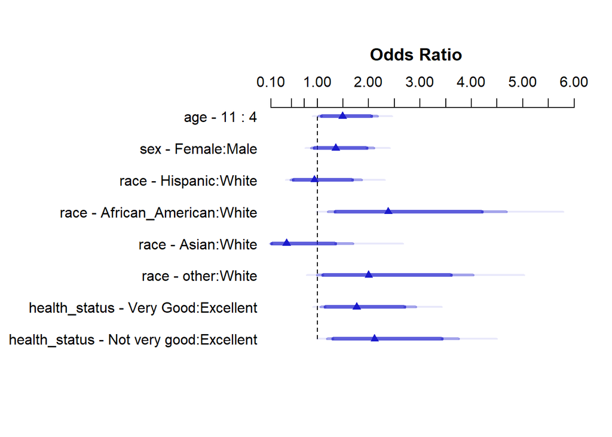

```r
plot(summary(mody_r))
```

We can also assess the relationship between each predictor and the outcome independently.

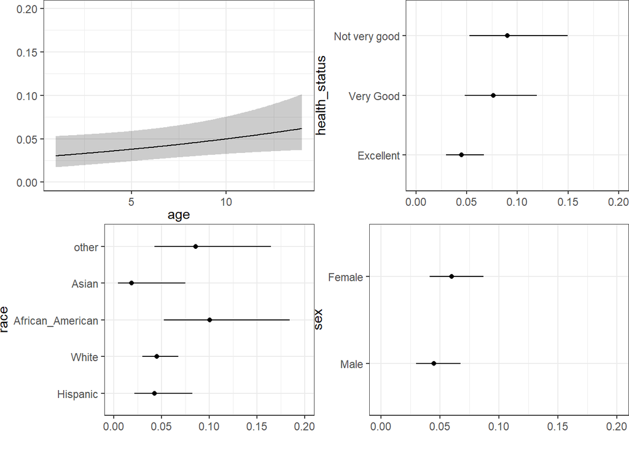

```r
ggplot(Predict(mody_r, fun = plogis))
```

### 9.3.3 Key fit summary statistics

```r
mody_r
```

```
Logistic Regression Model

lrm(formula = violence ~ sex + age + race + health_status, data = child22_si,
    x = TRUE, y = TRUE)

                      Model Likelihood      Discrimination    Rank Discrim.
                            Ratio Test             Indexes          Indexes
Obs          1191    LR chi2     29.43      R2       0.059    C       0.674
 0           1100    d.f.            8     R2(8,1191)0.018    Dxy     0.348
 1             91    Pr(> chi2) 0.0003    R2(8,252.1)0.081    gamma   0.352
max |deriv| 2e-11                           Brier    0.069    tau-a   0.049

                            Coef    S.E.   Wald Z Pr(>|Z|)
Intercept                   -3.5721 0.4259 -8.39  <0.0001
sex=Female                   0.3074 0.2232  1.38  0.1684
age                          0.0570 0.0277  2.06  0.0396
race=White                   0.0563 0.3473  0.16  0.8713
race=African_American        0.9244 0.4407  2.10  0.0359
race=Asian                  -0.8567 0.7870 -1.09  0.2763
race=other                   0.7494 0.4561  1.64  0.1004
health_status=Very Good      0.5690 0.2569  2.21  0.0268
health_status=Not very good  0.7495 0.2928  2.56  0.0105
```

Nagelkerke value is 0.059, which indicates that our model does not present an improvement compared to a null model. The C statistic value is 0.674, which indicates that the predictions of our model are not very reliable.

### 9.3.4 Confusion matrix

We will produce the confusion matrix using a cutting point of 0.08.

```r
mody_g_aug <- augment(mody_g, type.predict = "response")

cm <- confusionMatrix(
  data = factor(mody_g_aug$.fitted >= 0.08),
  reference = factor(mody_g_aug$violence == 1),
  positive = "TRUE")

cm
```

```
Confusion Matrix and Statistics

          Reference
Prediction FALSE TRUE
     FALSE   757   36
     TRUE    343   55

               Accuracy : 0.6818
                 95% CI : (0.6545, 0.7082)
    No Information Rate : 0.9236
    P-Value [Acc > NIR] : 1

                  Kappa : 0.1149

 Mcnemar's Test P-Value : <2e-16

            Sensitivity : 0.60440
            Specificity : 0.68818
         Pos Pred Value : 0.13819
         Neg Pred Value : 0.95460
             Prevalence : 0.07641
         Detection Rate : 0.04618
   Detection Prevalence : 0.33417
      Balanced Accuracy : 0.64629

       'Positive' Class : TRUE
```

The sensitivity of our model is 60.4%, the specificity is 68.8%, and the positive predictive value is 13.8%.

## 9.4 Non-linearity

Spearman $\rho^2$ plot

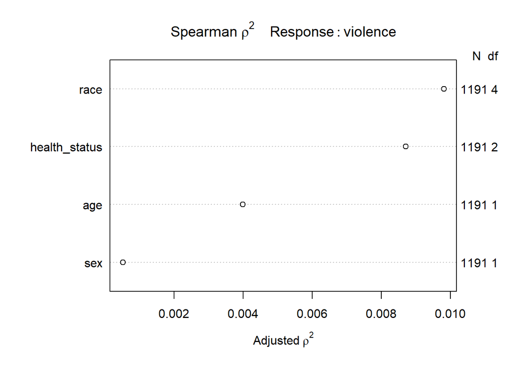

```r
plot(spearman2(violence ~ sex + age + race + health_status ,
            data = child22_si))
```

The Spearman $\rho^2$ plot is suggesting that `race` and `health_status` are the most suitable predictors for adding an interaction term. Since both variables are categorical, we will add an interaction term between `race` and `health_status`.

## 9.5 Model Z: incorporating non-linear terms

Now we will fit another model with an interaction term between `race` and `health_status`.

```r
modz_r <- lrm(violence ~ sex + age + race + health_status +
                 race %ia% health_status,
            data = child22_si, x = TRUE, y = TRUE)
```

Now we will confirm the number of additional degrees of freedom using anova:

```r
anova(modz_r)
```

```
                Wald Statistics          Response: violence

 Factor                                              Chi-Square d.f. P
 sex                                                  1.71       1   0.1914
 age                                                  4.40       1   0.0359
 race  (Factor+Higher Order Factors)                 15.56      12   0.2122
  All Interactions                                    4.67       8   0.7923
 health_status  (Factor+Higher Order Factors)        14.68      10   0.1440
  All Interactions                                    4.67       8   0.7923
 race * health_status  (Factor+Higher Order Factors)  4.67       8   0.7923
 TOTAL                                               32.94      16   0.0075
```

The interaction resulted in 8 additional degrees of freedom.

### 9.5.1 Modelz Results using `glm`

We can also use the glm function to produce tidied results of the interaction model.

```r
modz_g <- glm(violence ~ sex + age + race + health_status +
                 race %ia% health_status,
                 data =child22_si,
                 family =binomial(link =logit))
```

Tidied coefficients:

```r
tidy(modz_g, exponentiate = TRUE,
     conf.int = TRUE, conf.level = 0.95) |>
  select(term, estimate, std.error,
         low90 = conf.low, high90 = conf.high) |>
  gt() |>
  fmt_number(decimals = 3) |>
  tab_options(table.font.size = 14)
```

| term | estimate | std.error | low90 | high90 |
| --- | --- | --- | --- | --- |
| (Intercept) | 0.025 | 0.568 | 0.007 | 0.069 |
| sexFemale | 1.340 | 0.224 | 0.865 | 2.088 |
| age | 1.060 | 0.028 | 1.004 | 1.121 |
| raceWhite | 1.034 | 0.553 | 0.387 | 3.588 |
| raceAfrican_American | 4.955 | 0.664 | 1.392 | 20.109 |
| raceAsian | 1.188 | 0.892 | 0.159 | 6.415 |
| raceother | 2.128 | 0.735 | 0.479 | 9.465 |
| health_statusVery Good | 2.574 | 0.738 | 0.576 | 11.511 |
| health_statusNot very good | 1.996 | 0.796 | 0.374 | 9.610 |
| race %ia% health_statusrace=White * health_status=Very Good | 0.802 | 0.807 | 0.158 | 4.047 |
| race %ia% health_statusrace=White * health_status=Not very good | 1.587 | 0.879 | 0.280 | 9.725 |
| race %ia% health_statusrace=African_American * health_status=Very Good | 0.201 | 1.140 | 0.018 | 1.765 |
| race %ia% health_statusrace=African_American * health_status=Not very good | 0.426 | 1.055 | 0.052 | 3.532 |
| race %ia% health_statusrace=Asian * health_status=Very Good | 0.000 | 597.342 | 0.000 | 165.518 |
| race %ia% health_statusrace=Asian * health_status=Not very good | 0.000 | 720.840 | 0.000 | 0.000 |
| race %ia% health_statusrace=other * health_status=Very Good | 0.913 | 1.036 | 0.118 | 7.277 |
| race %ia% health_statusrace=other * health_status=Not very good | 0.971 | 1.231 | 0.076 | 10.872 |

### 9.5.2 Modelz Results using `lrm`

We will observe the plot of the effects using the `lrm` function:

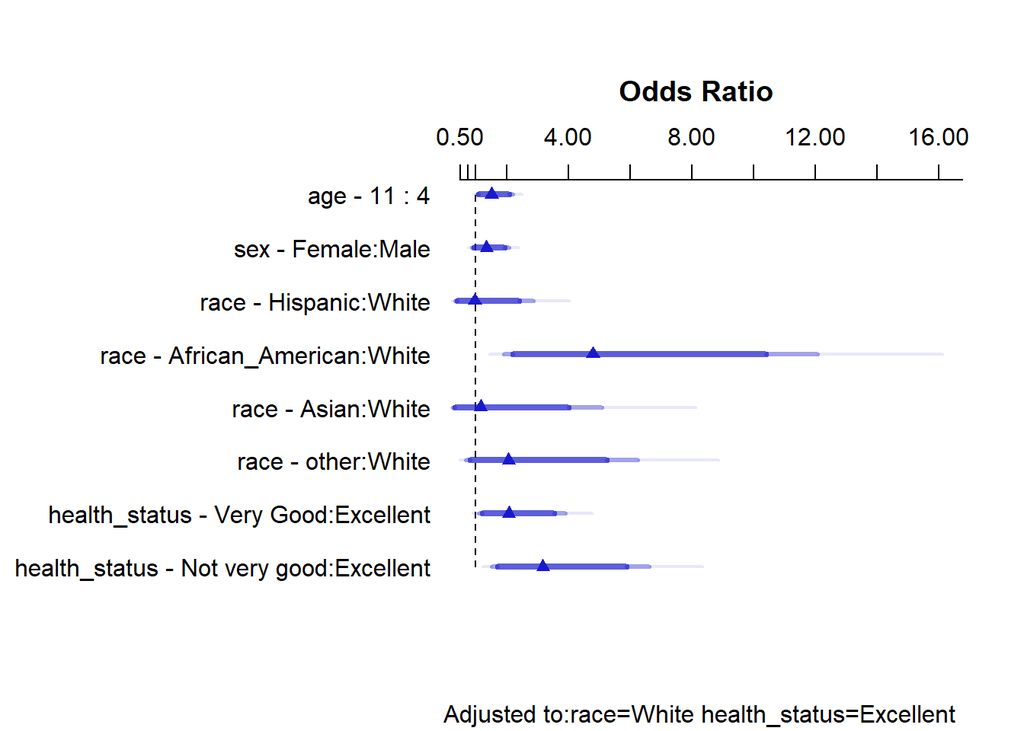

```r
plot(summary(modz_r))
```

We can also assess the relationship between each predictor and the outcome independently.

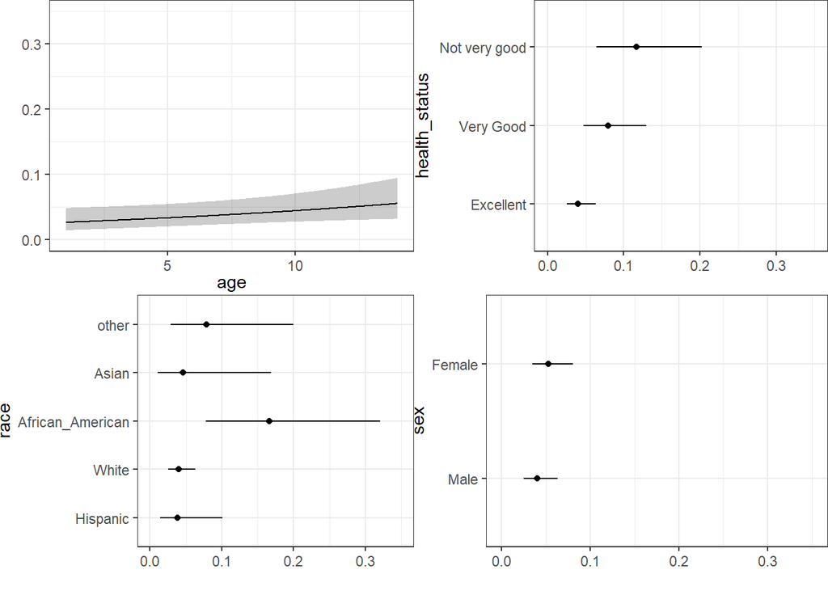

```r
ggplot(Predict(modz_r, fun = plogis))
```

### 9.5.3 Key fit summary statistics

```r
modz_r
```

```
Logistic Regression Model

lrm(formula = violence ~ sex + age + race + health_status + race %ia%
    health_status, data = child22_si, x = TRUE, y = TRUE)

                     Model Likelihood       Discrimination    Rank Discrim.
                           Ratio Test              Indexes          Indexes
Obs         1191    LR chi2     37.73       R2       0.075    C       0.682
 0          1100    d.f.           16     R2(16,1191)0.018    Dxy     0.365
 1            91    Pr(> chi2) 0.0017    R2(16,252.1)0.083    gamma   0.369
max |deriv| 0.02                            Brier    0.068    tau-a   0.052

                                                    Coef    S.E.    Wald Z
Intercept                                           -3.6802  0.5678 -6.48
sex=Female                                           0.2929  0.2242  1.31
age                                                  0.0585  0.0279  2.10
race=White                                           0.0334  0.5535  0.06
race=African_American                                1.6004  0.6636  2.41
race=Asian                                           0.1720  0.8922  0.19
race=other                                           0.7551  0.7355  1.03
health_status=Very Good                              0.9455  0.7384  1.28
health_status=Not very good                          0.6911  0.7955  0.87
race=White * health_status=Very Good                -0.2205  0.8066 -0.27
race=White * health_status=Not very good             0.4618  0.8791  0.53
race=African_American * health_status=Very Good     -1.6043  1.1401 -1.41
race=African_American * health_status=Not very good -0.8524  1.0549 -0.81
race=Asian * health_status=Very Good                -7.6789 30.3383 -0.25
race=Asian * health_status=Not very good            -7.5552 36.6268 -0.21
race=other * health_status=Very Good                -0.0913  1.0359 -0.09
race=other * health_status=Not very good            -0.0294  1.2306 -0.02
                                                    Pr(>|Z|)
Intercept                                           <0.0001
sex=Female                                          0.1914
age                                                 0.0359
race=White                                          0.9519
race=African_American                               0.0159
race=Asian                                          0.8471
race=other                                          0.3046
health_status=Very Good                             0.2003
health_status=Not very good                         0.3850
race=White * health_status=Very Good                0.7846
race=White * health_status=Not very good            0.5994
race=African_American * health_status=Very Good     0.1594
race=African_American * health_status=Not very good 0.4191
race=Asian * health_status=Very Good                0.8002
race=Asian * health_status=Not very good            0.8366
race=other * health_status=Very Good                0.9298
race=other * health_status=Not very good            0.9810
```

Negelkerke value is 0.075, which indicates that our model does not present an improvement compared to a null model. The C statistic value is 0.682, which indicates that the predictions of our model are not very reliable.

### 9.5.4 Confusion matrix

We will produce the confusion matrix using a cutting point of 0.08.

```r
modz_g_aug <- augment(modz_g, type.predict = "response")

cm <- confusionMatrix(
  data = factor(modz_g_aug$.fitted >= 0.08),
  reference = factor(modz_g_aug$violence == 1),
  positive = "TRUE")

cm
```

```
Confusion Matrix and Statistics

          Reference
Prediction FALSE TRUE
     FALSE   757   36
     TRUE    343   55

               Accuracy : 0.6818
                 95% CI : (0.6545, 0.7082)
    No Information Rate : 0.9236
    P-Value [Acc > NIR] : 1

                  Kappa : 0.1149

 Mcnemar's Test P-Value : <2e-16

            Sensitivity : 0.60440
            Specificity : 0.68818
         Pos Pred Value : 0.13819
         Neg Pred Value : 0.95460
             Prevalence : 0.07641
         Detection Rate : 0.04618
   Detection Prevalence : 0.33417
      Balanced Accuracy : 0.64629

       'Positive' Class : TRUE
```

The sensitivity of our model is 60.4%, the specificity is 68.8%, and the positive predictive value is 13.8%. These values match the main effects model `mody` values.

## 9.6 Validating the models

We will tidy the summaries of the main effects model `mody` and interaction model `modz` and compare them:

```r
temp1 <- bind_rows(glance(mody_g), glance(modz_g)) |>
  mutate(model = c("Y", "Z")) |>
  select(model, AIC, BIC)

temp2 <- tibble(model = c("Y", "Z"),
  auc = c(mody_r$stats["C"], modz_r$stats["C"]),
  r2_nag = c(mody_r$stats["R2"], modz_r$stats["R2"]))

left_join(temp1, temp2, by = "model") |>
  gt() |> fmt_number(columns = AIC:BIC, decimals = 1) |>
  fmt_number(columns = auc:r2_nag, decimals = 4) |>
  tab_options(table.font.size = 20)
```

| model | AIC | BIC | auc | r2_nag |
| --- | --- | --- | --- | --- |
| Y | 631.5 | 677.2 | 0.6740 | 0.0585 |
| Z | 639.2 | 725.6 | 0.6825 | 0.0748 |

The interaction model `modz` has a slightly better performance compared to the main effects model `mody`.

Now we will validate the models to determine our final model:

```r
set.seed(432)
valY <- validate(mody_r, B = 40)
valZ <- validate(modz_r, B = 40)

val_1 <- bind_rows(valY[1,], valZ[1,]) |>
  mutate(model = c("Y", "Z"),
         AUC_nominal = 0.5 + (index.orig/2),
         AUC_validated = 0.5 + (index.corrected/2)) |>
  select(model, AUC_nominal, AUC_validated)

val_2 <- bind_rows(valY[2,], valZ[2,]) |>
  mutate(model = c("Y", "Z"),
         R2_nominal = index.orig,
         R2_validated = index.corrected) |>
  select(model, R2_nominal, R2_validated)

val <- left_join(val_1, val_2, by = "model")

val |> gt() |> fmt_number(decimals = 4) |>
  tab_options(table.font.size = 20)
```

[output not shown]

After validating the area under the curve value (AUC) and the R2 value, the main effects model `mody` displayed improved performance compared to the interaction model `modz`.

## 9.7 Final Model

After validating the models, the main effects model `mody` yielded better results. Both the Nagelkerke’s R squared and ROC values were improved compared to the interaction `modz` model. The main effects model `mody` will be the model of choice in this case.

The main effects model `mody` parameters and their coefficients with a 95% confidence interval is displayed in the following table:

```r
tidy(mody_g, exponentiate = TRUE,
     conf.int = TRUE, conf.level = 0.95) |>
  select(term, estimate, std.error,
         low95 = conf.low, high95 = conf.high,
         p = p.value) |>
  gt() |>
  fmt_number(decimals = 3) |>
  tab_options(table.font.size = 20)
```

| term | estimate | std.error | low95 | high95 | p |
| --- | --- | --- | --- | --- | --- |
| (Intercept) | 0.028 | 0.426 | 0.012 | 0.062 | 0.000 |
| sexFemale | 1.360 | 0.223 | 0.879 | 2.114 | 0.168 |
| age | 1.059 | 0.028 | 1.003 | 1.119 | 0.040 |
| raceWhite | 1.058 | 0.347 | 0.556 | 2.194 | 0.871 |
| raceAfrican_American | 2.520 | 0.441 | 1.062 | 6.082 | 0.036 |
| raceAsian | 0.425 | 0.787 | 0.064 | 1.654 | 0.276 |
| raceother | 2.116 | 0.456 | 0.857 | 5.229 | 0.100 |
| health_statusVery Good | 1.766 | 0.257 | 1.059 | 2.911 | 0.027 |
| health_statusNot very good | 2.116 | 0.293 | 1.173 | 3.717 | 0.010 |

To observe the effect sizes we will display the effect plot:

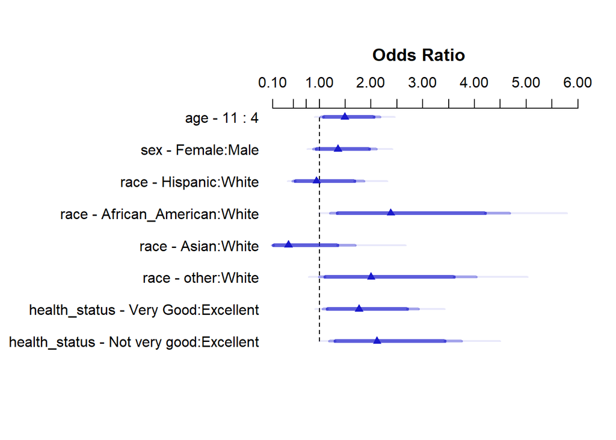

```r
plot(summary(mody_r))
```

According to this model, an 11 year old child has 1.5 the odds of witnessing/experiencing violence compared to a 4 year old child, when all other variables are held constant. Female children have about 1.4 times the odds of witnessing/experiencing violence compared to their male counterparts, also holding all other variables constant. When observing race, African American children have about 2.4 the odds witnessing/experiencing violence compared to White children, followed by Other races (2.0). Hispanic have about the same odds of witnessing/experiencing violence (about 1.0) while Asian children have lower odds of witnessing/experiencing violence (about 0.4) compared to White children. Compared to children with excellent health status, those with very good health status have about 1.7 the odds of witnessing/experiencing violence, while those with not very good health status have about 2.0 the odds of witnessing/experiencing violence. Again, these assumption are made when all other variables are held constant.

ROC Curve Plot

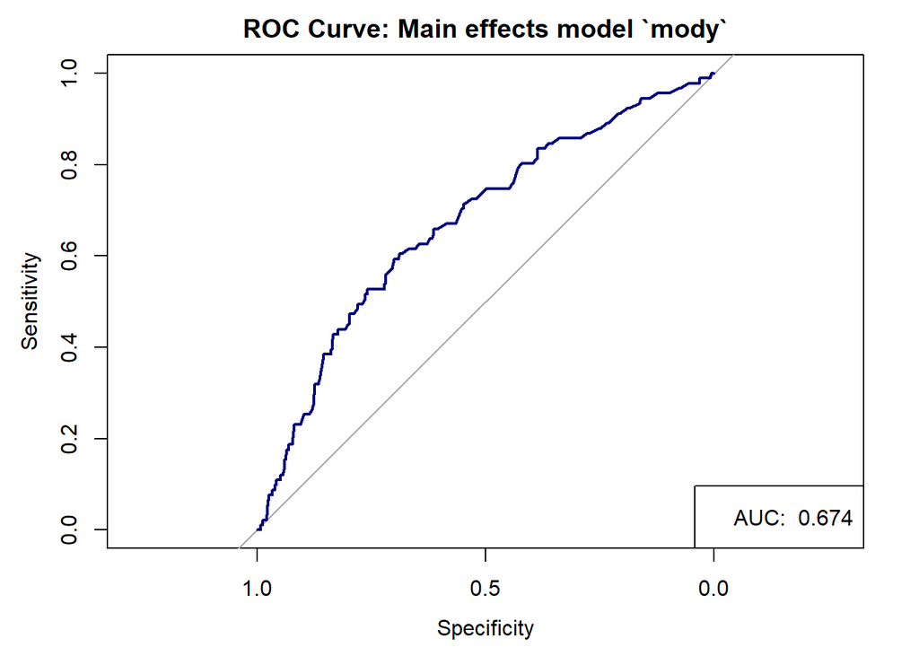

```r
predict.prob1 <- predict(mody_g, type = "response")
roc1 <- pROC::roc(mody_g$data$violence, predict.prob1)

plot(roc1, main = "ROC Curve: Main effects model `mody`", lwd = 2, col = "navy")
legend('bottomright', legend = paste("AUC: ",
                                     round_half_up(auc(roc1),4)))
```

The AUC values displayed here is the *nominal* AUC.

Validated Nagelkerke R-squared and the C statistic values

```r
set.seed(432)
valY <- validate(mody_r, B = 40)

val_1 <- bind_rows(valY[1,]) |>
  mutate(model = c("Y"),
         AUC_nominal = 0.5 + (index.orig/2),
         AUC_validated = 0.5 + (index.corrected/2)) |>
  select(model, AUC_nominal, AUC_validated)

val_2 <- bind_rows(valY[2,]) |>
  mutate(model = c("Y"),
         R2_nominal = index.orig,
         R2_validated = index.corrected) |>
  select(model, R2_nominal, R2_validated)

val <- left_join(val_1, val_2, by = "model")

val |> gt() |> fmt_number(decimals = 4) |>
  tab_options(table.font.size = 20)
```

| model | AUC_nominal | AUC_validated | R2_nominal | R2_validated |
| --- | --- | --- | --- | --- |
| Y | 0.6740 | 0.6376 | 0.0585 | 0.0223 |

The validated area under the curve (AUC) value is 0.638. This means that our model’s predictions are slightly better than a random guess. The validated Nagelkerke’s R squared value is 0.022, which means that our model does not show an improvement compared to a null model.

Using the nomogram to make a prediction:

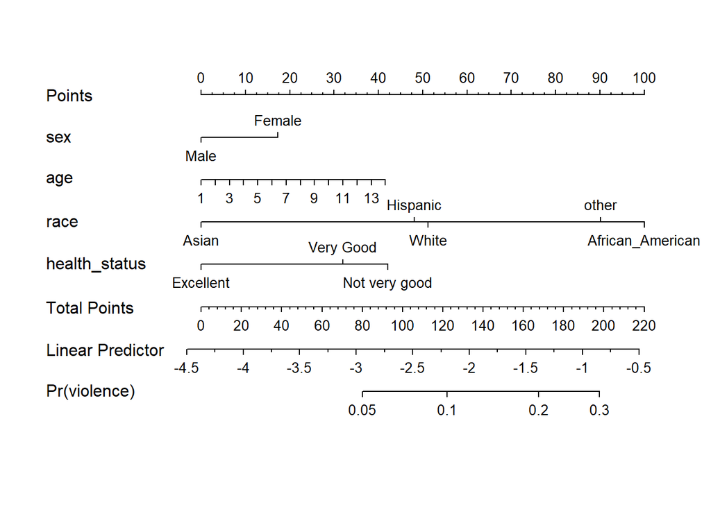

```r
plot(nomogram(mody_r, fun = plogis,
            fun.at = c(0.05, seq(0.1, 0.9, by = 0.1), 0.95),
            funlabel = "Pr(violence)"))
```

# 10 Discussion

The first research question was: Among children in the Midwest, Do specific social factors (age, sex, race, health status, and parental educational level) contribute to their mental health status score? Based on the final linear regression model, a couple of the social factors contributed meaningfully to the outcome, specifically, **race** (Asian) and **health status** (not very good). Having an Asian race contributed positively to the mental health score, while having a not very good health status contributed negatively.

Project A was a challenging, yet achievable project. One of the prominent issues we faced was that the outcome of the linear regression model was discrete. There were a few difficulties during the analysis, and we wished we were more proficient in other suitable methods such as the Poisson or negative binomial regression. Another challenge was choosing an appropriate transformation for the outcome. We used the Box-Cox to guide us, however that was not useful. So, we opted for a different transformation until reaching a satisfying result. We realized that the Box-Cox can be misleading. We also wished we had collapsed some of the categorical levels as they had used more degrees of freedom in the model. However, this decision may compromise our ability to investigate meaningful differences between the categorical levels. The overall process of the project was not difficult as there was a roadmap guiding us (the instructions). However, making decisions on the order of the logistic models (the main effects model and interaction model using glm and lrm function) was confusing at times. We decided to organize the models in a way that facilitated comprehension for the audience. We learned that it is imperative to keep our study goal in mind during the analysis process.

# 11 Affirmation

I am certain that it is completely appropriate for these data to be shared with anyone, without any conditions. There are no concerns about privacy or security.

# 12 References

- Centers for Disease Control and Prevention. (2023, June 29). NHIS - 2022 NHIS. Centers for Disease Control and Prevention. https://www.cdc.gov/nchs/nhis/2022nhis.htm.